# StatInfProject

Jeff Wolbach

Sunday, August 17, 2014

```r
longdata=numeric(length=1500)
for (i in 1:1500) { longdata[i]=mean(rexp(40,0.2))}
mld<-mean(longdata)
sdld<-sd(longdata)
```

The distribution of the means of each sample is described in the following histogram.

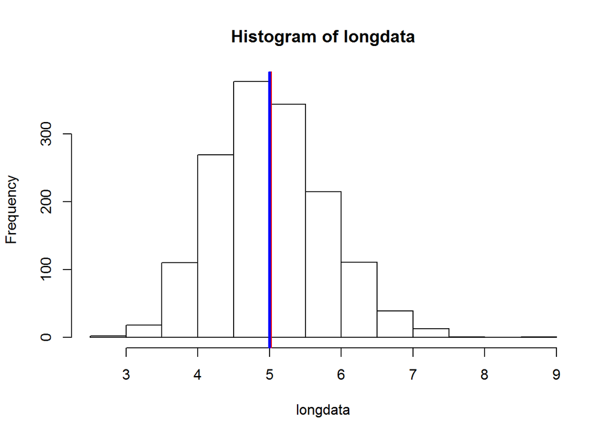

The average of the calculated sample means (5.0143) is represented in the histogram as a vertical red line, and the true population mean (5.000) is represented in the histogram as a vertical blue line.

As proof of the normality of the distribution of the sample means, we can calculate the fraction of the sample means that differ from the average of the sample means by specific fractions of the variance of the sample means.

```r
norm_comp=matrix(nrow=5,ncol=2)
for (j in 1:5) {
  norm_comp[j,1]<- round(mean(longdata < (mld - (j*0.5)*sdld)),3)
  norm_comp[j,2]<- round(mean((mld + (j*0.5)*sdld) < longdata),3)
}
```

Where the first column of norm_comp represents values below the average of the sample means (to the left), and the second column represents values above the average of the sample means (to the right). For a normal distribution the two elements of each row should be equal, or the distribution should be symmetric about the center.

```r
norm_comp
```

[output not shown]

The coverage of the confidence interval for (1/lambda) is calculated

```r
ul<-mean(longdata)+1.96*sd(longdata)
ll<-mean(longdata)-1.96*sd(longdata)
cover<-mean(ll<longdata & ul>longdata)
cover
```

```
## [1] 0.9527
```

This result is very close to the theoretical coverage of 95% (or, 0.95), assuming a normal distribution.